# F<sub>st</sub> Summary

Will Pitchers

9 November 2015

These results draw from the results files generated with a 100kb window, stepped at 50kb intervals.

Firstly, the VCFtools F<sub>st</sub> calculator emits both ‘raw’ and ‘adjusted’ F<sub>st</sub> values, so let’s take a look at how closely these two measures predict one another…

The plot below shows the relationship of the two F<sub>st</sub> estimates across all scaffolds and all 15 comparisons (the red line is 1:1). The R<sup>2</sup> for the correlation here is 0.93, suggesting that it *probably* doesn’t matter a great deal which statistic we use – though the adjusted F<sub>st</sub> is generally somewhat higher.

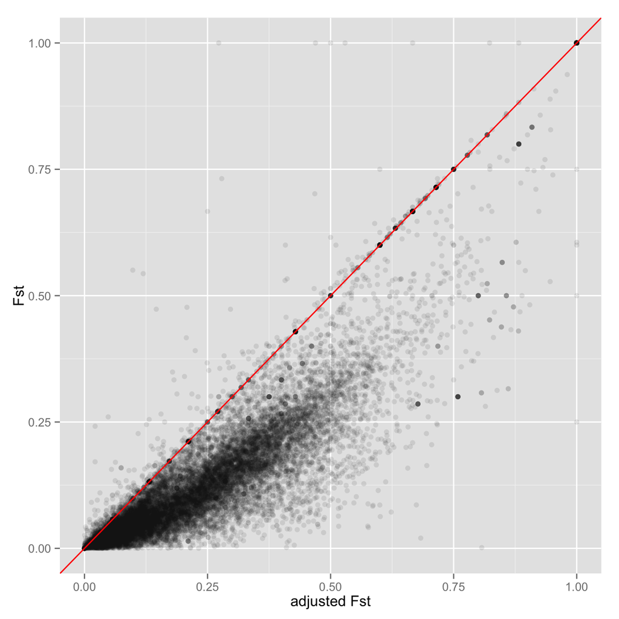

However, there *does* seem to be a difference when it comes to the consistency of F<sub>st</sub> bewteen scaffolds; here illustrated with just (the SSR-bearing) scaffolds 4, 8, 22, 60 & 77.

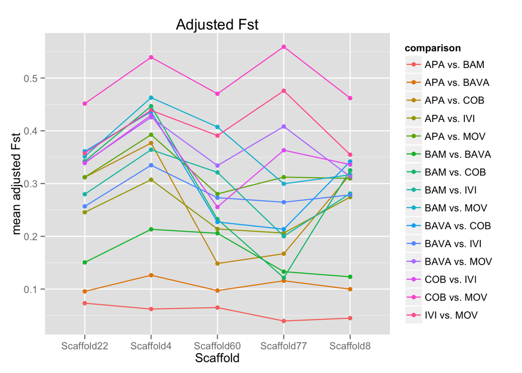

Note the increase in crossing over and the greater variablility in some of the comparisons, particularly those involving *BAM* and *BAVA*.

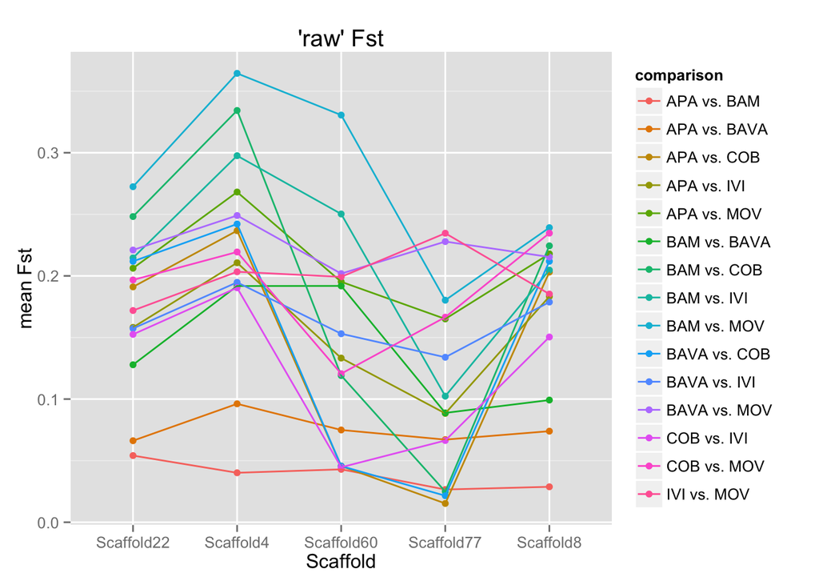

Taking a slightly deeper look, lets see if we can get some idea of the variation *within* scaffolds – I’ll start with the SSR-bearing scaffolds for want of a more compelling place to start.

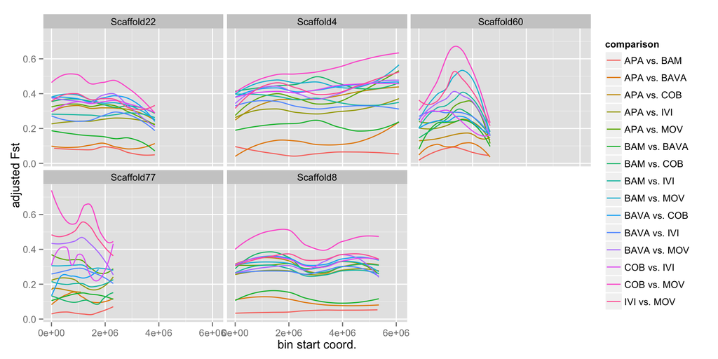

So in this plot we can see a few things; firstly, that the ordering of the comparisons doesn’t change an awful lot between *or* along these scaffolds. Secondly, there is noticeably more variability along scaffolds 60 & 77 than along the (longer) 4, 22 & 8.

To put that numerically the variance in F<sub>st</sub> along these ranges from 10^{-4} to 0.042. The COB_MOV comparison is the most variable over all (var. of 0.0263881), and APA_BAM the least variable (var of 0.001071).

```r
# can we get a distribution of Fsts across the genome with varying window size?
```